# A-SA25204160-2025-11-10

SA25204160

2025-11-16

## Question

### 11.6

实现一个随机游走 Metropolis 采样器，用于生成标准拉普拉斯分布（参见练习 3.3.2）。对于增量，从正态分布中模拟。比较当建议分布使用不同方差时生成的链。同时，计算每条链的接受率。

### 11.10

此例出现在 [41] 中。考虑二元密度

$f(x,y) \propto \binom{n}{x} y^{x+a-1} (1-y)^{n-x+b-1}, \quad x = 0,1,\ldots,n,\ 0 \leq y \leq 1.$

可以证明对于固定的 $a,b,n$，条件分布为：

$X \mid Y = y \sim \text{Binomial}(n, y)$

$Y \mid X = x \sim \text{Beta}(x + a, n - x + b)$

使用 Gibbs 采样器生成一个目标联合密度为 f(x,y) 的链。

### homework

考虑模型：$P(Y=1|X_1, X_2, X_3) = \frac{1}{1+e^{-(a+b_1X_1+b_2X_2+b_3X_3)}}$,其中：$X_1 \sim \text{Poi}(1)$,$X_2 \sim \text{Exp}(1)$,$X_3 \sim \text{B}(1, 0.5)$,

(1):编写一个函数实现类似于 P11 的功能,其输入参数为 $N, b_1, b_2, b_3, f_0$，输出值为 $\alpha$。

(2):调用该函数，输入参数为 $N = 10^6, b_1 = 1, b_2 = 1, b_3 = -1$，$f_0 = 0.1, 0.01, 0.001, 0.0001$。

(3):绘制 $-\log(f_0)$ 与 $\alpha$ 的散点图。

## Answer

### 11.6

#### 11.6.1

定义目标分布 - 标准拉普拉斯分布

#### 11.6.2

实现随机游走Metropolis采样器

#### 11.6.3

使用不同方差的建议分布运行链

#### 11.6.4

比较结果

```
## === 练习题 11.6 结果 ===
```

```
## 提议方差 = 0.1, 接受率 = 0.963
## 提议方差 = 0.5, 接受率 = 0.829
## 提议方差 = 1.0, 接受率 = 0.701
## 提议方差 = 2.0, 接受率 = 0.511
## 提议方差 = 5.0, 接受率 = 0.274
```

#### 11.6.5

可视化比较

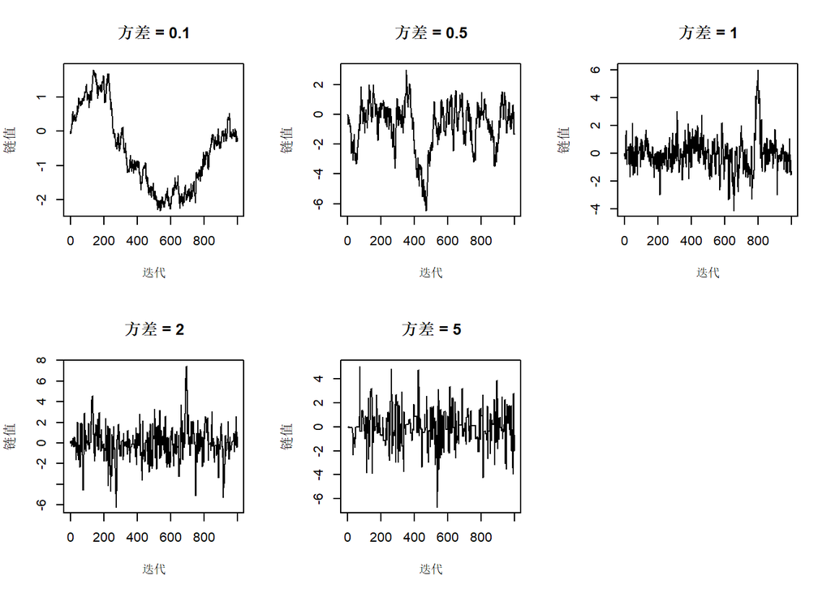

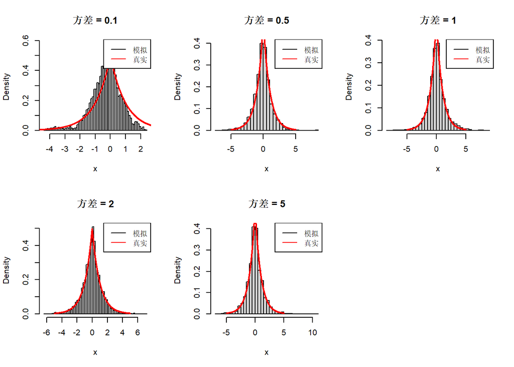

### 11.10

#### 11.10.1

定义参数

#### 11.10.2

实现Gibbs采样器

#### 11.10.3

运行Gibbs采样器

#### 11.10.4

分析结果

```
## === 练习题 11.10 结果 ===
```

```
## x的均值: 3.947
```

```
## y的均值: 0.395
```

```
## x的方差: 5.946
```

```
## y的方差: 0.039
```

#### 11.10.5

可视化

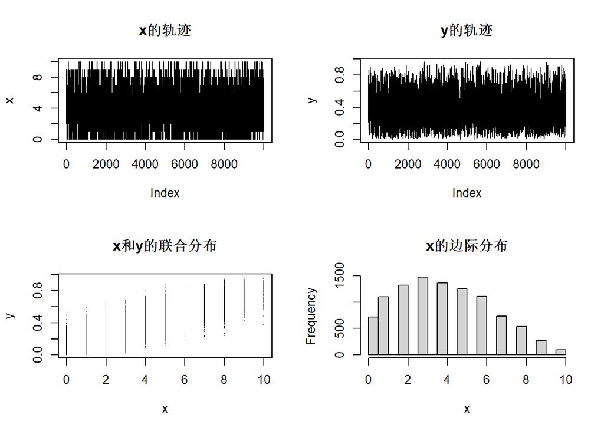

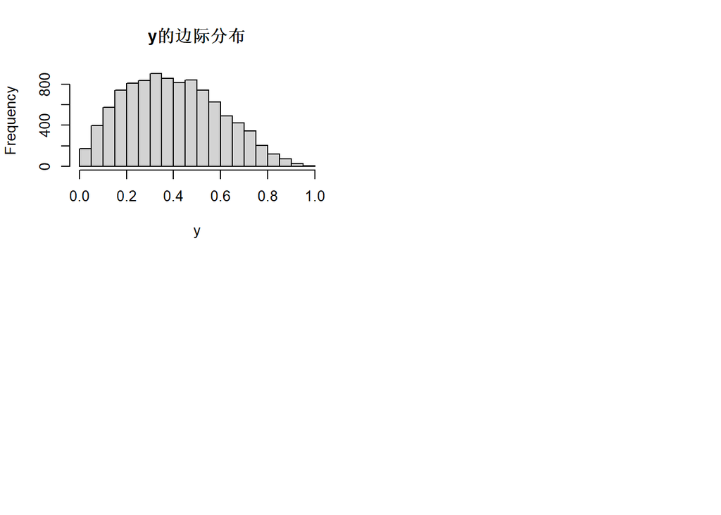

### homework

#### (1)

定义求解alpha的函数

#### (2)

调用函数计算不同f0对应的alpha

```
## === 课后作业结果 ===
```

```
## f0 = 0.1000, alpha = -4.49667
## f0 = 0.0100, alpha = -7.58259
## f0 = 0.0010, alpha = -10.27795
## f0 = 0.0001, alpha = -12.89039
```

#### (3)

绘制 -log(f0) vs alpha 散点图

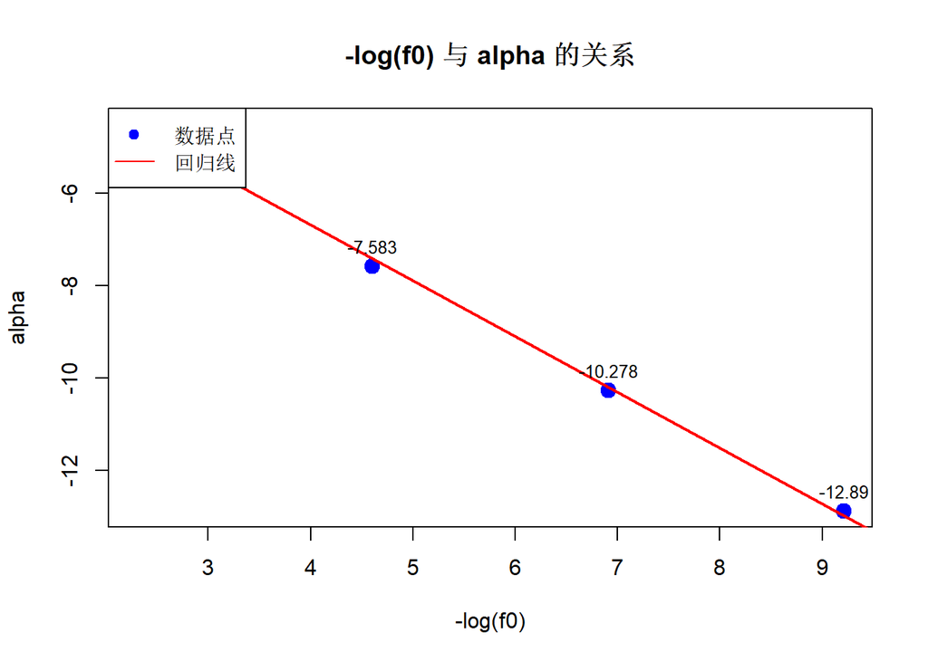

```
##
## -log(f0) 与 alpha 的相关系数: -0.9992
```